# NYC taxi trips tip prediction

Lovdip Singh

## Goal of study

To analyse NYC Taxi data and fit a model to predict taxi tips.

## Cleaning the data

Tips are only for credit card data, we begin by only considering payments made by credit card.

Renaming pickup and drop off time variables will be helpful for clarity and deriving other variables. This includes the day of week variable, the hour the trip started and the duration of the trip.

An extra_costs variable will also be added by summing existing extra, mta_tax, improvement_surcharge, tolls_amount variables.

```r
# read in file
w2 <- read_csv('../data/taxi/week2.csv')
nrow(w2)
```

```
## [1] 2651287
```

```r
w2 <- w2 %>%
  filter(payment_type == 1) %>% # tips are only for credit card payment type
  mutate(dropoff_datetime = tpep_dropoff_datetime,
         pickup_datetime = tpep_pickup_datetime,
         dow = factor(wday(pickup_datetime,label=TRUE,abbr=TRUE, week_start=1), ordered = FALSE), #add day of week
         hour_trip_start = as.numeric(hour(pickup_datetime)), # add hour trip started
         trip_duration = as.numeric(difftime(dropoff_datetime,pickup_datetime,units="mins"))) # trip duration in minutes

# create extra_costs variable
w2 <- w2 %>% select(extra, mta_tax, improvement_surcharge, tolls_amount) %>%
  transmute(extra_costs = rowSums(.)) %>%
  bind_cols(w2, .)
summary(w2)
```

```
##     VendorID     tpep_pickup_datetime          tpep_dropoff_datetime
##  Min.   :1.000   Min.   :2016-01-08 00:00:00   Min.   :2016-01-08 00:01:23
##  1st Qu.:1.000   1st Qu.:2016-01-09 18:43:58   1st Qu.:2016-01-09 18:58:16
##  Median :2.000   Median :2016-01-11 17:07:20   Median :2016-01-11 17:21:40
##  Mean   :1.534   Mean   :2016-01-11 15:11:35   Mean   :2016-01-11 15:26:08
##  3rd Qu.:2.000   3rd Qu.:2016-01-13 12:30:57   3rd Qu.:2016-01-13 12:46:49
##  Max.   :2.000   Max.   :2016-01-14 23:59:59   Max.   :2016-01-15 23:39:18
##
##  passenger_count trip_distance     pickup_longitude pickup_latitude
##  Min.   :0.000   Min.   :  0.000   Min.   :-78.38   Min.   : 0.00
##  1st Qu.:1.000   1st Qu.:  1.050   1st Qu.:-73.99   1st Qu.:40.74
##  Median :1.000   Median :  1.740   Median :-73.98   Median :40.75
##  Mean   :1.647   Mean   :  2.961   Mean   :-72.86   Mean   :40.14
##  3rd Qu.:2.000   3rd Qu.:  3.170   3rd Qu.:-73.97   3rd Qu.:40.77
##  Max.   :9.000   Max.   :191.900   Max.   :  0.00   Max.   :42.36
##
##    RatecodeID    store_and_fwd_flag dropoff_longitude dropoff_latitude
##  Min.   : 1.00   Length:1773438     Min.   :-99.75    Min.   : 0.00
##  1st Qu.: 1.00   Class :character   1st Qu.:-73.99    1st Qu.:40.73
##  Median : 1.00   Mode  :character   Median :-73.98    Median :40.75
##  Mean   : 1.04                      Mean   :-73.00    Mean   :40.21
##  3rd Qu.: 1.00                      3rd Qu.:-73.96    3rd Qu.:40.77
##  Max.   :99.00                      Max.   :  0.00    Max.   :52.75
##
##   payment_type  fare_amount         extra            mta_tax
##  Min.   :1     Min.   :-52.00   Min.   :-0.5000   Min.   :-0.500
##  1st Qu.:1     1st Qu.:  6.50   1st Qu.: 0.0000   1st Qu.: 0.500
##  Median :1     Median :  9.50   Median : 0.0000   Median : 0.500
##  Mean   :1     Mean   : 12.56   Mean   : 0.3299   Mean   : 0.498
##  3rd Qu.:1     3rd Qu.: 14.00   3rd Qu.: 0.5000   3rd Qu.: 0.500
##  Max.   :1     Max.   :998.00   Max.   : 2.0000   Max.   : 2.220
##
##    tip_amount        tolls_amount      improvement_surcharge  total_amount
##  Min.   :-220.800   Min.   :  0.0000   Min.   :-0.3          Min.   :-227.10
##  1st Qu.:   1.290   1st Qu.:  0.0000   1st Qu.: 0.3          1st Qu.:   9.30
##  Median :   2.000   Median :  0.0000   Median : 0.3          Median :  12.35
##  Mean   :   2.583   Mean   :  0.3181   Mean   : 0.3          Mean   :  16.58
##  3rd Qu.:   2.950   3rd Qu.:  0.0000   3rd Qu.: 0.3          3rd Qu.:  17.88
##  Max.   : 900.000   Max.   :100.0000   Max.   : 0.3          Max.   :1297.75
##
##  dropoff_datetime              pickup_datetime                dow
##  Min.   :2016-01-08 00:01:23   Min.   :2016-01-08 00:00:00   Mon:227691
##  1st Qu.:2016-01-09 18:58:16   1st Qu.:2016-01-09 18:43:58   Tue:249055
##  Median :2016-01-11 17:21:40   Median :2016-01-11 17:07:20   Wed:270827
##  Mean   :2016-01-11 15:26:08   Mean   :2016-01-11 15:11:35   Thu:272284
##  3rd Qu.:2016-01-13 12:46:49   3rd Qu.:2016-01-13 12:30:57   Fri:259279
##  Max.   :2016-01-15 23:39:18   Max.   :2016-01-14 23:59:59   Sat:262940
##                                                              Sun:231362
##  hour_trip_start trip_duration       extra_costs
##  Min.   : 0.00   Min.   : -43.950   Min.   : -1.300
##  1st Qu.: 9.00   1st Qu.:   6.567   1st Qu.:  0.800
##  Median :14.00   Median :  10.583   Median :  1.300
##  Mean   :13.71   Mean   :  14.555   Mean   :  1.446
##  3rd Qu.:19.00   3rd Qu.:  16.650   3rd Qu.:  1.300
##  Max.   :23.00   Max.   :1439.883   Max.   :100.800
##
```

```r
nrow(w2)
```

```
## [1] 1773438
```

Filtering by credit card payments only has reduced the number of trips by 877,849.

There are a few concerns on some data. There are unusually large trip_distances, trip_duration, fare_amount, tip_amount, tolls_amount. RatecodeID should only take values 1 to 6, some negative values for dollar variables and distances. Negative values clearly wont be helpful in the model, so these observations will have to be discarded.

We can check the values of the variables with relatively large max values to determine appropriate cutoff values for the variables.

```r
table(cut(w2$trip_distance, seq(0,200, by=10)))
```

```
##
##    (0,10]   (10,20]   (20,30]   (30,40]   (40,50]   (50,60]   (60,70]   (70,80]
##   1673242     85878      8072       360        86        35        10         4
##   (80,90]  (90,100] (100,110] (110,120] (120,130] (130,140] (140,150] (150,160]
##         4         1         1         2         0         0         0         0
## (160,170] (170,180] (180,190] (190,200]
##         0         0         0         1
```

Trip distances $\leq 30$ miles seems appropriate. There is a clear around the 200 mile mark, the vast majority of trips are under 10 miles.

```r
w2 <- w2 %>% filter(trip_distance <= 30 & trip_distance > 0)

table(cut(w2$trip_duration, seq(0,1500, by=100))) # trip duration 0-1500
```

```
##
##           (0,100]         (100,200]         (200,300]         (300,400]
##           1764920               151                27                21
##         (400,500]         (500,600]         (600,700]         (700,800]
##                20                22                15                11
##         (800,900]       (900,1e+03]   (1e+03,1.1e+03] (1.1e+03,1.2e+03]
##                11                24                17                11
## (1.2e+03,1.3e+03] (1.3e+03,1.4e+03] (1.4e+03,1.5e+03]
##                 8               186              1705
```

```r
table(cut(w2$trip_duration, seq(0,100, by=10))) # trip duration 0-100
```

```
##
##   (0,10]  (10,20]  (20,30]  (30,40]  (40,50]  (50,60]  (60,70]  (70,80]
##   823740   643324   202547    61040    20707     8127     3426     1374
##  (80,90] (90,100]
##      470      165
```

After filtering the trip distance, there are still some extreme duration values. Clear errors in trip duration, there are quite a few (~1700) trips over 1400 minutes, which is an unusually large amount, most likely sensors that are left on for a day as 1400 minutes ~24 hours. Trip duration $\leq 100$ minutes seems appropriate.

```r
w2 <- w2 %>% filter(trip_duration <= 100 & trip_duration > 0)
table(cut(w2$tip_amount, seq(0,600, by=50))) # tip amount 0-600
```

```
##
##    (0,50]  (50,100] (100,150] (150,200] (200,250] (250,300] (300,350] (350,400]
##   1709281        99        12         1         2         4         0         0
## (400,450] (450,500] (500,550] (550,600]
##         0         0         0         0
```

```r
table(cut(w2$tip_amount, seq(0,100, by=5))) # tip amount 0-100
```

```
##
##    (0,5]   (5,10]  (10,15]  (15,20]  (20,25]  (25,30]  (30,35]  (35,40]
##  1554975   115833    34140     3286      621      197      102       54
##  (40,45]  (45,50]  (50,55]  (55,60]  (60,65]  (65,70]  (70,75]  (75,80]
##       36       37       22       19        9       17       10        9
##  (80,85]  (85,90]  (90,95] (95,100]
##        7        1        1        4
```

Taking the tip amount with a limit of $\$20$ seems appropriate, there are large amounts of data available for these numbers which is good. Higher values are likely to hinder the model. This also means that our model can only generalise to tips between $\$0$ and $\$20$.

```r
w2$RatecodeID <- as.character(w2$RatecodeID)
w2 <- w2 %>%
  filter(passenger_count %in% c(1:6), # max 6 passengers
         RatecodeID %in% as.character(c(1:6)), # valid values for RatecodeID
         tip_amount <= 20 & tip_amount >= 0)

summary(w2)
```

```
##     VendorID     tpep_pickup_datetime          tpep_dropoff_datetime
##  Min.   :1.000   Min.   :2016-01-08 00:00:00   Min.   :2016-01-08 00:02:21
##  1st Qu.:1.000   1st Qu.:2016-01-09 18:44:17   1st Qu.:2016-01-09 18:57:07
##  Median :2.000   Median :2016-01-11 17:08:26   Median :2016-01-11 17:21:42
##  Mean   :1.533   Mean   :2016-01-11 15:12:20   Mean   :2016-01-11 15:25:18
##  3rd Qu.:2.000   3rd Qu.:2016-01-13 12:31:30   3rd Qu.:2016-01-13 12:46:09
##  Max.   :2.000   Max.   :2016-01-14 23:59:59   Max.   :2016-01-15 01:09:34
##
##  passenger_count trip_distance    pickup_longitude pickup_latitude
##  Min.   :1.000   Min.   : 0.010   Min.   :-78.38   Min.   : 0.00
##  1st Qu.:1.000   1st Qu.: 1.060   1st Qu.:-73.99   1st Qu.:40.74
##  Median :1.000   Median : 1.750   Median :-73.98   Median :40.75
##  Mean   :1.648   Mean   : 2.951   Mean   :-72.92   Mean   :40.17
##  3rd Qu.:2.000   3rd Qu.: 3.170   3rd Qu.:-73.97   3rd Qu.:40.77
##  Max.   :6.000   Max.   :30.000   Max.   :  0.00   Max.   :42.36
##
##   RatecodeID        store_and_fwd_flag dropoff_longitude dropoff_latitude
##  Length:1763705     Length:1763705     Min.   :-99.75    Min.   : 0.00
##  Class :character   Class :character   1st Qu.:-73.99    1st Qu.:40.73
##  Mode  :character   Mode  :character   Median :-73.98    Median :40.75
##                                        Mean   :-73.05    Mean   :40.24
##                                        3rd Qu.:-73.96    3rd Qu.:40.77
##                                        Max.   :  0.00    Max.   :52.75
##
##   payment_type  fare_amount        extra           mta_tax
##  Min.   :1     Min.   :  0.0   Min.   :0.0000   Min.   :0.0000
##  1st Qu.:1     1st Qu.:  6.5   1st Qu.:0.0000   1st Qu.:0.5000
##  Median :1     Median :  9.5   Median :0.0000   Median :0.5000
##  Mean   :1     Mean   : 12.4   Mean   :0.3307   Mean   :0.4988
##  3rd Qu.:1     3rd Qu.: 14.0   3rd Qu.:0.5000   3rd Qu.:0.5000
##  Max.   :1     Max.   :600.0   Max.   :2.0000   Max.   :0.5000
##
##    tip_amount      tolls_amount     improvement_surcharge  total_amount
##  Min.   : 0.000   Min.   : 0.0000   Min.   :0.0           Min.   :  0.00
##  1st Qu.: 1.300   1st Qu.: 0.0000   1st Qu.:0.3           1st Qu.:  9.30
##  Median : 2.000   Median : 0.0000   Median :0.3           Median : 12.35
##  Mean   : 2.543   Mean   : 0.3086   Mean   :0.3           Mean   : 16.38
##  3rd Qu.: 2.950   3rd Qu.: 0.0000   3rd Qu.:0.3           3rd Qu.: 17.80
##  Max.   :20.000   Max.   :70.5000   Max.   :0.3           Max.   :600.30
##
##  dropoff_datetime              pickup_datetime                dow
##  Min.   :2016-01-08 00:02:21   Min.   :2016-01-08 00:00:00   Mon:226444
##  1st Qu.:2016-01-09 18:57:07   1st Qu.:2016-01-09 18:44:17   Tue:247724
##  Median :2016-01-11 17:21:42   Median :2016-01-11 17:08:26   Wed:269468
##  Mean   :2016-01-11 15:25:18   Mean   :2016-01-11 15:12:20   Thu:270840
##  3rd Qu.:2016-01-13 12:46:09   3rd Qu.:2016-01-13 12:31:30   Fri:257892
##  Max.   :2016-01-15 01:09:34   Max.   :2016-01-14 23:59:59   Sat:261455
##                                                              Sun:229882
##  hour_trip_start trip_duration        extra_costs
##  Min.   : 0.00   Min.   :  0.01667   Min.   : 0.000
##  1st Qu.: 9.00   1st Qu.:  6.58333   1st Qu.: 0.800
##  Median :14.00   Median : 10.60000   Median : 1.300
##  Mean   :13.71   Mean   : 12.96624   Mean   : 1.438
##  3rd Qu.:19.00   3rd Qu.: 16.63333   3rd Qu.: 1.300
##  Max.   :23.00   Max.   :100.00000   Max.   :70.800
##
```

There are still some large values for fare amount.

```r
table(cut(w2$fare_amount, seq(0,600, by=50))) # fare amount 0-600
```

```
##
##    (0,50]  (50,100] (100,150] (150,200] (200,250] (250,300] (300,350] (350,400]
##   1721295     42143       196        24        14         1         1         1
## (400,450] (450,500] (500,550] (550,600]
##         0         0         0         1
```

```r
table(cut(w2$fare_amount, seq(0,100, by=10))) # tip amount 0-100
```

```
##
##   (0,10]  (10,20]  (20,30]  (30,40]  (40,50]  (50,60]  (60,70]  (70,80]
##  1009324   527390   121705    49829    13047    38525     2335      916
##  (80,90] (90,100]
##      220      147
```

Clear outliers, taking a cutoff of $\$100$ seems good.

```r
w2 <- w2 %>% filter(fare_amount <= 100 & fare_amount > 0)
summary(w2)
```

```
##     VendorID     tpep_pickup_datetime          tpep_dropoff_datetime
##  Min.   :1.000   Min.   :2016-01-08 00:00:00   Min.   :2016-01-08 00:02:21
##  1st Qu.:1.000   1st Qu.:2016-01-09 18:44:14   1st Qu.:2016-01-09 18:57:05
##  Median :2.000   Median :2016-01-11 17:08:24   Median :2016-01-11 17:21:40
##  Mean   :1.533   Mean   :2016-01-11 15:12:20   Mean   :2016-01-11 15:25:17
##  3rd Qu.:2.000   3rd Qu.:2016-01-13 12:31:31   3rd Qu.:2016-01-13 12:46:10
##  Max.   :2.000   Max.   :2016-01-14 23:59:59   Max.   :2016-01-15 01:09:34
##
##  passenger_count trip_distance    pickup_longitude pickup_latitude
##  Min.   :1.000   Min.   : 0.010   Min.   :-78.38   Min.   : 0.00
##  1st Qu.:1.000   1st Qu.: 1.060   1st Qu.:-73.99   1st Qu.:40.74
##  Median :1.000   Median : 1.740   Median :-73.98   Median :40.75
##  Mean   :1.648   Mean   : 2.948   Mean   :-72.92   Mean   :40.17
##  3rd Qu.:2.000   3rd Qu.: 3.170   3rd Qu.:-73.97   3rd Qu.:40.77
##  Max.   :6.000   Max.   :29.900   Max.   :  0.00   Max.   :42.36
##
##   RatecodeID        store_and_fwd_flag dropoff_longitude dropoff_latitude
##  Length:1763438     Length:1763438     Min.   :-99.75    Min.   : 0.00
##  Class :character   Class :character   1st Qu.:-73.99    1st Qu.:40.73
##  Mode  :character   Mode  :character   Median :-73.98    Median :40.75
##                                        Mean   :-73.05    Mean   :40.24
##                                        3rd Qu.:-73.96    3rd Qu.:40.77
##                                        Max.   :  0.00    Max.   :52.75
##
##   payment_type  fare_amount         extra           mta_tax
##  Min.   :1     Min.   :  2.50   Min.   :0.0000   Min.   :0.0000
##  1st Qu.:1     1st Qu.:  6.50   1st Qu.:0.0000   1st Qu.:0.5000
##  Median :1     Median :  9.50   Median :0.0000   Median :0.5000
##  Mean   :1     Mean   : 12.38   Mean   :0.3308   Mean   :0.4989
##  3rd Qu.:1     3rd Qu.: 14.00   3rd Qu.:0.5000   3rd Qu.:0.5000
##  Max.   :1     Max.   :100.00   Max.   :2.0000   Max.   :0.5000
##
##    tip_amount      tolls_amount     improvement_surcharge  total_amount
##  Min.   : 0.000   Min.   : 0.0000   Min.   :0.0           Min.   :  3.30
##  1st Qu.: 1.300   1st Qu.: 0.0000   1st Qu.:0.3           1st Qu.:  9.30
##  Median : 2.000   Median : 0.0000   Median :0.3           Median : 12.35
##  Mean   : 2.542   Mean   : 0.3078   Mean   :0.3           Mean   : 16.36
##  3rd Qu.: 2.950   3rd Qu.: 0.0000   3rd Qu.:0.3           3rd Qu.: 17.80
##  Max.   :20.000   Max.   :60.9500   Max.   :0.3           Max.   :136.34
##
##  dropoff_datetime              pickup_datetime                dow
##  Min.   :2016-01-08 00:02:21   Min.   :2016-01-08 00:00:00   Mon:226393
##  1st Qu.:2016-01-09 18:57:05   1st Qu.:2016-01-09 18:44:14   Tue:247679
##  Median :2016-01-11 17:21:40   Median :2016-01-11 17:08:24   Wed:269437
##  Mean   :2016-01-11 15:25:17   Mean   :2016-01-11 15:12:20   Thu:270798
##  3rd Qu.:2016-01-13 12:46:10   3rd Qu.:2016-01-13 12:31:31   Fri:257855
##  Max.   :2016-01-15 01:09:34   Max.   :2016-01-14 23:59:59   Sat:261430
##                                                              Sun:229846
##  hour_trip_start trip_duration        extra_costs
##  Min.   : 0.00   Min.   :  0.01667   Min.   : 0.000
##  1st Qu.: 9.00   1st Qu.:  6.58333   1st Qu.: 0.800
##  Median :14.00   Median : 10.60000   Median : 1.300
##  Mean   :13.71   Mean   : 12.96398   Mean   : 1.437
##  3rd Qu.:19.00   3rd Qu.: 16.63333   3rd Qu.: 1.300
##  Max.   :23.00   Max.   :100.00000   Max.   :61.750
##
```

```r
nrow(w2)
```

```
## [1] 1763438
```

Everything seems good, after this filtration, 10,000 trips were removed.

We can create some categorical variables from the numeric data as linear relationships may be more likely to be present in these categories rather than numeric data. Lets use the hour_trip_start variable and create time_of_day variable for each 6 hour interval of a day. For example if a trip starts in the hours between midnight and 6am lets call this early morning, etc..

```r
w2$time_of_day <- NA
w2$time_of_day[w2$hour_trip_start >= 0 & w2$hour_trip_start <= 5] <- 'early morning'
w2$time_of_day[w2$hour_trip_start >= 6 & w2$hour_trip_start <= 11] <- 'morning'
w2$time_of_day[w2$hour_trip_start >= 12 & w2$hour_trip_start <= 17] <- 'evening'
w2$time_of_day[w2$hour_trip_start >= 17 & w2$hour_trip_start <= 23] <- 'night'
w2$time_of_day <- factor(w2$time_of_day, levels=c('early morning', 'morning','evening', 'night'))

w2 %>% group_by(time_of_day) %>% summarise(n()) %>% arrange(time_of_day)
```

```
## # A tibble: 4 x 2
##   time_of_day    `n()`
##   <fct>          <int>
## 1 early morning 190537
## 2 morning       447495
## 3 evening       410370
## 4 night         715036
```

We can also use pick up longitude and latitude values to make sure all pickups are in NYC and also classify each pick up by their respective borough. This can be done by using a shapefile for NYC.

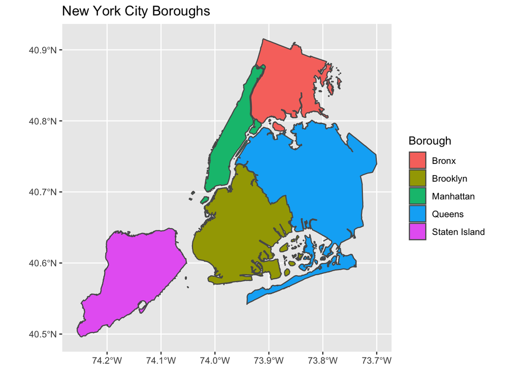

```r
nyc_boro <- read_sf('geo_export_8bbd3dcd-7071-42e8-a21f-8adb61e9e2ee.shp')

(map <- ggplot() +
  geom_sf(data=nyc_boro, aes(fill=boro_name)) +
  labs(title="New York City Boroughs", fill='Borough'))
```

Lets classify pick up coordinates to their particular NYC borough to filter non NYC pick ups.

```r
coords = w2[,c('pickup_longitude', 'pickup_latitude')]
pnts_sf <- st_as_sf(coords, coords=c('pickup_longitude', 'pickup_latitude'), crs = st_crs(nyc_boro))
boroughs <- pnts_sf %>% mutate(
  intersection=as.integer(st_intersects(geometry, nyc_boro)),
  borough = ifelse(is.na(intersection), NA, nyc_boro$boro_name[intersection])
)
```

```
## although coordinates are longitude/latitude, st_intersects assumes that they are planar
## although coordinates are longitude/latitude, st_intersects assumes that they are planar
```

```r
w2 <- w2 %>%
  mutate(pickup_borough = boroughs$borough)

w2 %>% group_by(pickup_borough) %>%
  summarise(count=n()) %>%
  arrange(desc(count))
```

```
## # A tibble: 6 x 2
##   pickup_borough   count
##   <chr>            <int>
## 1 Manhattan      1620556
## 2 Queens           91244
## 3 <NA>             25939
## 4 Brooklyn         24985
## 5 Bronx              707
## 6 Staten Island        7
```

Most pickups were in Manhattan. Queens had the second highest. Bronx and Staten Island had much fewer pick ups.

25,939 were not classified in a borough, lets plot these trips as points on the map to see any patterns.

```r
sum(w2$pickup_longitude == 0 & w2$pickup_latitude == 0)
```

```
## [1] 25078
```

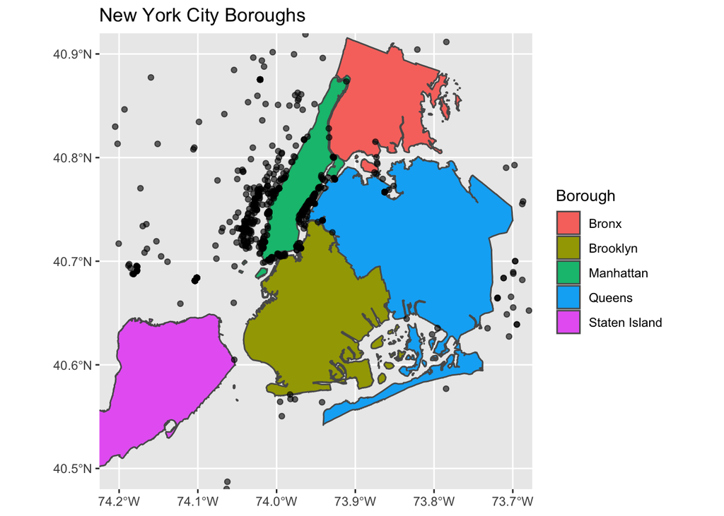

```r
not_nyc <- w2%>% filter(is.na(pickup_borough)) %>%
  select(pickup_longitude,pickup_latitude) %>%
  filter(pickup_longitude != 0 & pickup_latitude != 0) %>%
  st_as_sf(coords=c(1, 2), crs='WGS84')


map + geom_sf(data=not_nyc, alpha=0.6) + coord_sf(xlim = c(-74.2, -73.7), ylim = c(40.5, 40.9))
```

25,078 of these points had longitude/latitude as 0, which is an obvious error.

```r
w2 <- w2 %>%
  na.omit()

nrow(w2)
```

```
## [1] 1737499
```

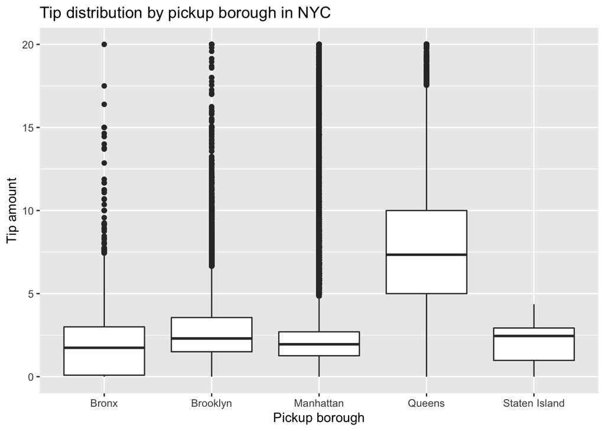

```r
w2 %>% ggplot(aes(x=pickup_borough, y=tip_amount)) + geom_boxplot() + ylim(c(0,20)) +
  labs(title='Tip distribution by pickup borough in NYC', x='Pickup borough', y='Tip amount')
```

It appears the median tip for pickups in Queens is much higher than the rest of the boroughs, lets investigate further.

```r
w2 %>% group_by(pickup_borough) %>%
  summarise(n(), median=median(tip_amount)) %>%
  arrange(desc(median))
```

```
## # A tibble: 5 x 3
##   pickup_borough   `n()` median
##   <chr>            <int>  <dbl>
## 1 Queens           91244   7.34
## 2 Staten Island        7   2.45
## 3 Brooklyn         24985   2.3
## 4 Manhattan      1620556   1.95
## 5 Bronx              707   1.74
```

Quite a difference, median seems to be around 2 for other regions but 7 for Queens. It would be worth adding a binary variable queens which takes the value 1 if the pick pick up was in Queens, 0 otherwise. This would also help memory issues in model selection instead of including all boroughs.

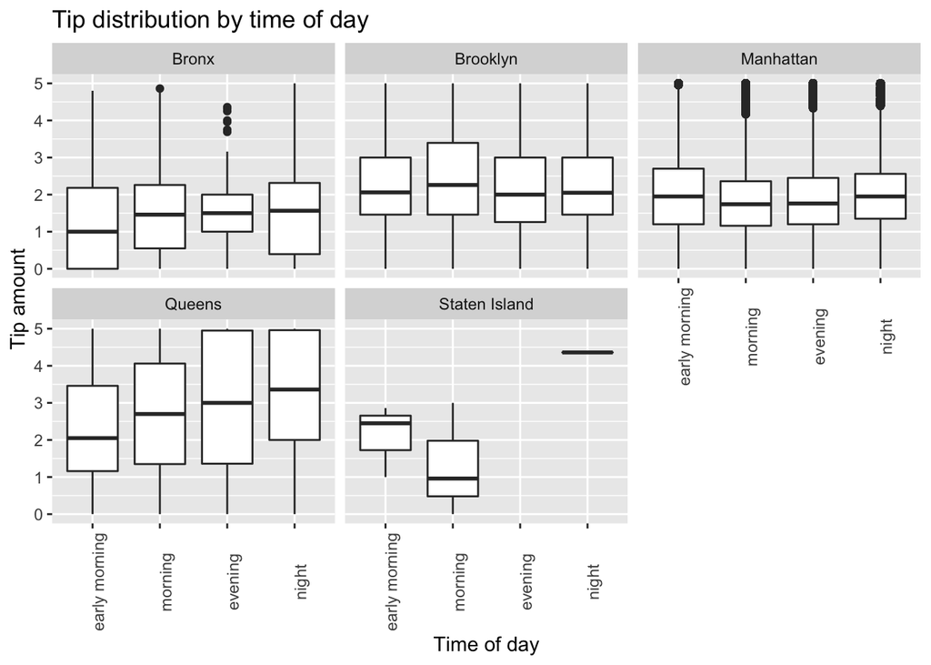

```r
w2 <- w2 %>% mutate(queens = as.factor(as.numeric(w2$pickup_borough=='Queens')))

w2%>% ggplot(aes(x=time_of_day, y=tip_amount)) + geom_boxplot() + ylim(c(0,5)) +
  facet_wrap(~pickup_borough) +
  labs(title='Tip distribution by time of day', x='Time of day', y='Tip amount') +
  theme(axis.text.x = element_text(angle = 90))
```

Not much data on Staten island. Tips in Queens higher, Bronx lower, which could reflect the socio-demographics of the areas.

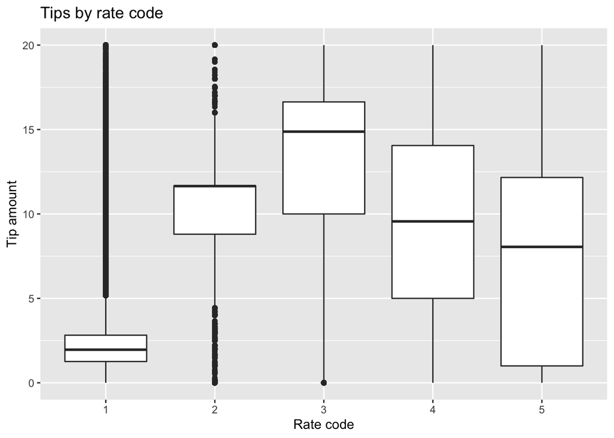

```r
w2%>% ggplot(aes(x=RatecodeID, y=tip_amount)) + geom_boxplot() + ylim(c(0,20)) +
  labs(title='Tips by rate code', x='Rate code', y='Tip amount')
```

```r
w2 %>% group_by(RatecodeID) %>%
  summarise(n(), median=median(tip_amount))
```

```
## # A tibble: 5 x 3
##   RatecodeID   `n()` median
##   <chr>        <int>  <dbl>
## 1 1          1699368   1.96
## 2 2            33956  11.6
## 3 3             2118  14.9
## 4 4              464   9.56
## 5 5             1593   8.05
```

It appears that trips on the standard rate have a lower median tip. Another binary variable may be helpful, whether the trip was on a standard rate or not.

```r
w2 <- w2 %>% mutate(standard_rate = as.factor(as.numeric(w2$RatecodeID=='1')))
```

```r
tip_prop <- w2$tip_amount/w2$fare_amount
mean(tip_prop)
```

```
## [1] 0.2154325
```

```r
median(tip_prop)
```

```
## [1] 0.2214286
```

The average proportion of tips is about 20% of the fare amount which is consistent with NYC tourist advice.

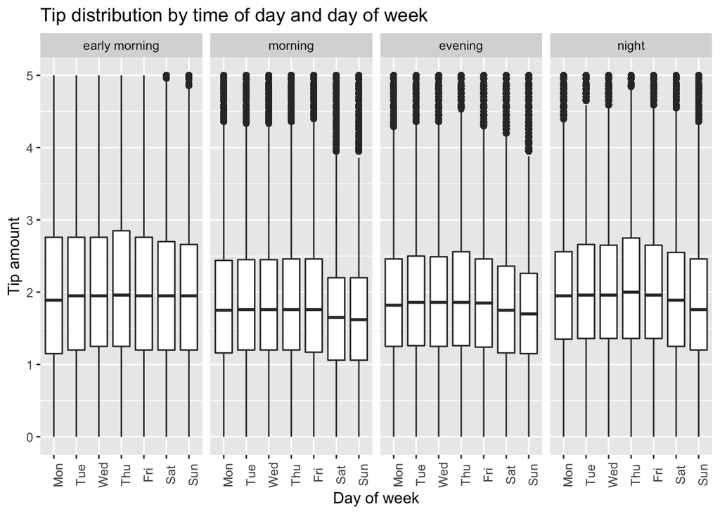

```r
w2 %>% ggplot(aes(x=dow, y=tip_amount, group=dow)) + geom_boxplot() + facet_grid(~time_of_day) + ylim(c(0,5)) + theme(axis.text.x = element_text(angle = 90)) + labs(title='Tip distribution by time of day and day of week', x='Day of week', y='Tip amount')
```

The tips in weekends appear to be lower than tips in weekdays.

## Model building

Cross validation code:

```r
allyhat <- function(xtrain, ytrain, xtest, lambdas, nvmax=50){
  n <- nrow(xtrain)
  yhat <- matrix(nrow=nrow(xtest), ncol=length(lambdas))
  search <- regsubsets(xtrain, ytrain, nvmax=nvmax, method="back")
  summ <- summary(search)
  for(i in 1:length(lambdas)){
    penMSE <- n * log(summ$rss) + lambdas[i] * (1:(nvmax))
    best <- which.min(penMSE)  #lowest AIC
    betahat <- coef(search, best) #coefficients
    xinmodel <- cbind(1,xtest)[,summ$which[best,]] #predictors in that model
    yhat[,i] <- xinmodel %*% betahat
  }
  yhat
}
```

There will be 8 variables included in the linear model for prediction of tips.

To get an unbiased estimate of the mean squared prediction error for week 2 data we can use 10 fold cross validation. The strategy is to do backwards step wise search to find the model with the smallest penalised RSS, for a given $\lambda$ parameter. $\text{Penalised (RSS)}(\lambda) = nlog\text{RSS}+\lambda p$. Regsubsets will find the best models with 1 to 50 parameters, we can the use the RSS of these models to find the model with the lowest penalised RSS for each value of $\lambda$. The predicted values of the model are recorded for each of the test sets. This results is an unbiased estimate of mean squared prediction error for each of the values of $\lambda$.

```r
set.seed(6288842)

# variables to be included in model
subset <- w2[, c('extra_costs',
                 'standard_rate',
                 'fare_amount',
                 'dow',
                 'queens',
                 'trip_duration',
                 'trip_distance',
                 'time_of_day',
                 'tip_amount')]



mf <- model.frame(tip_amount~.^2, data=subset)
X <- model.matrix(tip_amount~.^2, mf)[,-1]
y <- subset$tip_amount
n <- nrow(X)

set.seed(6288842)
folds <- sample(rep(1:10, length.out=n))

lambdas <- c(2,4,6,8,10,12)
fitted <- matrix(nrow=n, ncol=length(lambdas))

for(k in 1:10){
  train <- (1:n)[folds!=k]
  test <- (1:n)[folds==k]
  fitted[test,] <- allyhat(X[train,], y[train], X[test,], lambdas)
}

colMeans((y - fitted)^2)
```

```
## [1] 1.395328 1.395328 1.395328 1.395328 1.395328 1.395338
```

Cross validation shows that $\lambda=2$ is fine to use, there is little difference in MSPE between models using the different values of $\lambda$.

```r
search = regsubsets(X, y, nvmax = 50, method = "backward")
summ = summary(search)
aic = n * log(summ$rss) + 2 * (1:50)
best = which.min(aic)
betahat = coef(search, best)

betahat
```

```
##                       (Intercept)                       extra_costs
##                      3.8532903121                      0.1250006340
##                    standard_rate1                       fare_amount
##                     -3.6663960048                      0.0588235720
##                            dowSat                            dowSun
##                      0.0831084968                      0.2249132881
##                           queens1                     trip_distance
##                     -0.5847082051                      0.2133650191
##                time_of_daymorning                time_of_dayevening
##                     -0.3720606225                     -0.5259495070
##                  time_of_daynight        extra_costs:standard_rate1
##                     -0.4797744159                      0.1172423660
##           extra_costs:fare_amount                extra_costs:dowSat
##                      0.0009426540                     -0.0408465588
##                extra_costs:dowSun               extra_costs:queens1
##                     -0.0456852204                     -0.0241819394
##         extra_costs:trip_duration    extra_costs:time_of_daymorning
##                     -0.0012219171                      0.0658927106
##    extra_costs:time_of_dayevening        standard_rate1:fare_amount
##                      0.0359781699                      0.0754437315
##             standard_rate1:dowSun            standard_rate1:queens1
##                     -0.1724631064                      0.5881116635
##      standard_rate1:trip_distance standard_rate1:time_of_daymorning
##                     -0.1025093354                      0.2478776229
## standard_rate1:time_of_dayevening   standard_rate1:time_of_daynight
##                      0.4081552937                      0.3789528136
##                fare_amount:dowSat                fare_amount:dowSun
##                     -0.0083764727                     -0.0023292180
##               fare_amount:queens1         fare_amount:trip_distance
##                      0.0244437425                     -0.0021606165
##    fare_amount:time_of_daymorning    fare_amount:time_of_dayevening
##                      0.0344286764                      0.0315713553
##      fare_amount:time_of_daynight                    dowTue:queens1
##                      0.0207359554                     -0.1150564337
##                    dowWed:queens1                    dowThu:queens1
##                     -0.1202478246                     -0.2128656037
##                    dowFri:queens1                    dowSat:queens1
##                     -0.1974802635                     -0.1236461078
##              dowTue:trip_distance              dowWed:trip_distance
##                      0.0089693072                      0.0137638288
##              dowThu:trip_distance              dowSat:trip_distance
##                      0.0135956238                      0.0198347570
##         dowSat:time_of_dayevening             queens1:trip_distance
##                     -0.0430739164                     -0.0353344395
##        queens1:time_of_dayevening          queens1:time_of_daynight
##                     -0.0741105558                      0.2325444133
##       trip_duration:trip_distance  trip_duration:time_of_daymorning
##                      0.0009084253                     -0.0046363902
##  trip_distance:time_of_daymorning  trip_distance:time_of_dayevening
##                     -0.0765790083                     -0.0581609169
##    trip_distance:time_of_daynight
##                     -0.0316708932
```

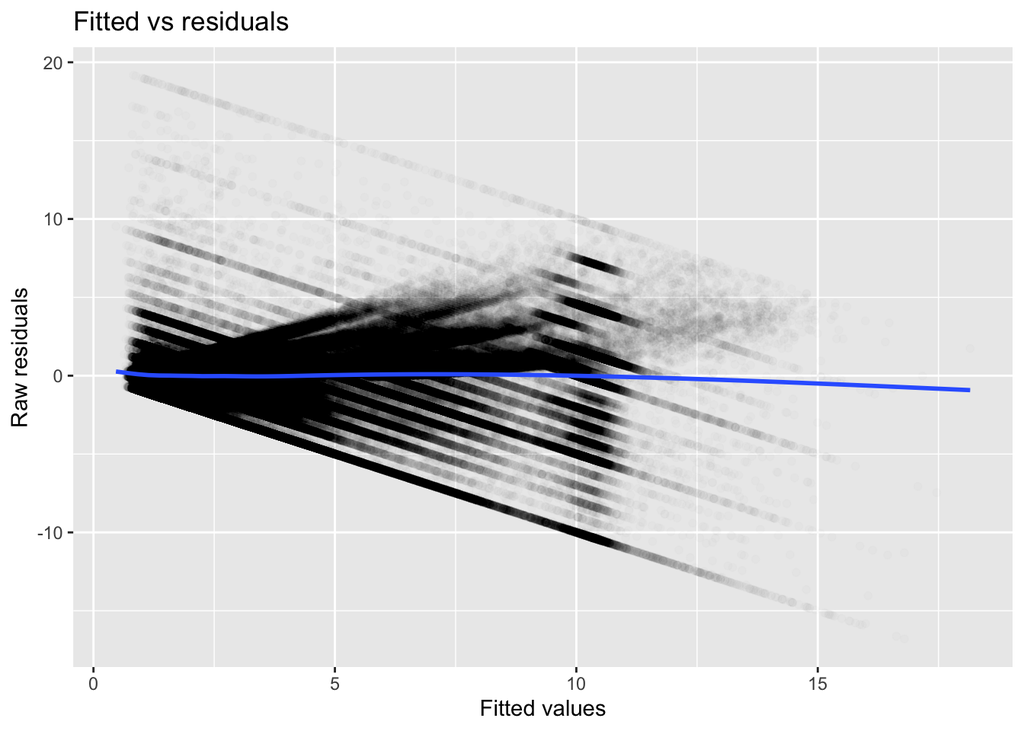

```r
mf <- model.frame(tip_amount~.^2, data=subset)
Xfull <- model.matrix(tip_amount~.^2, mf)[,summ$which[best,]]
fitted <-  Xfull %*% betahat

y_yhat <- data.frame(y=y,yhat=fitted)

y_yhat %>% ggplot(aes(x=yhat,y=y-fitted)) + geom_point(alpha=0.01) + geom_smooth() +
  labs(title='Fitted vs residuals', x='Fitted values', y='Raw residuals')
```

Residual plot seems good, residuals are centred around zero, variance overall seems ok, there are some large predicted values for small actual values and vice versa.

## Applying the model

Cleaning the data of week 4 2016 NYC taxi trips using the same steps as week 2 data, and calculating the mean squared prediction error using the model generated with week 2 data:

```r
# read in file
w4 <- read_csv('../data/taxi/week4.csv')
# rename and add useful columns
w4 <- w4 %>%
  mutate(dropoff_datetime = tpep_dropoff_datetime,
         pickup_datetime = tpep_pickup_datetime,
         dow = factor(wday(pickup_datetime,label=TRUE,abbr=TRUE, week_start=1), ordered = FALSE), #add day of week
         hour_trip_start = as.numeric(hour(pickup_datetime)), # add hour trip started
         trip_duration = as.numeric(difftime(dropoff_datetime,pickup_datetime,units="mins"))) #trip duration in minutes


w4 <- w4 %>% select(extra, mta_tax, improvement_surcharge, tolls_amount) %>%
  transmute(extra_costs = rowSums(.)) %>%
  bind_cols(w4, .)

w2$RatecodeID <- as.character(w2$RatecodeID)
# filter valid data
w4 <- w4 %>%
  filter(payment_type == 1, #tip_amount is for credit payment only
         passenger_count %in% c(1:6), #max 6 passengers
         RatecodeID %in% as.character(c(1:6)),
         fare_amount <= 100 & fare_amount > 0,
         trip_duration <= 100 & trip_duration > 0,
         trip_distance <= 30 & trip_distance > 0,
         tip_amount <= 20 & tip_amount >= 0)

# add pickup borough
coords = w4[,c('pickup_latitude', 'pickup_longitude')]
ny_boro <- read_sf('geo_export_8bbd3dcd-7071-42e8-a21f-8adb61e9e2ee.shp')
pnts_sf <- st_as_sf(coords, coords=c('pickup_longitude', 'pickup_latitude'), crs = st_crs(ny_boro))
boroughs <- pnts_sf %>% mutate(
  intersection=as.integer(st_intersects(geometry, ny_boro)),
  borough = ifelse(is.na(intersection), NA, ny_boro$boro_name[intersection])
)
```

```
## although coordinates are longitude/latitude, st_intersects assumes that they are planar
```

```
## although coordinates are longitude/latitude, st_intersects assumes that they are planar
```

```r
# remove pick ups not in NYC borough
w4 <- w4 %>%
  mutate(pickup_borough = boroughs$borough) %>%
  na.omit() #only include observations with a valid borough

# categorise hour_trip_start to time of day
w4$time_of_day <- NA
w4$time_of_day[w4$hour_trip_start >= 0 & w4$hour_trip_start <= 5] <- 'early morning'
w4$time_of_day[w4$hour_trip_start >= 6 & w4$hour_trip_start <= 11] <- 'morning'
w4$time_of_day[w4$hour_trip_start >= 12 & w4$hour_trip_start <= 17] <- 'evening'
w4$time_of_day[w4$hour_trip_start >= 17 & w4$hour_trip_start <= 23] <- 'night'
w4$time_of_day <- as.factor(w4$time_of_day)

# add binary variables queens and standard_rate
w4 <- w4 %>% mutate(queens = as.factor(as.numeric(w4$pickup_borough=='Queens')))
w4 <- w4 %>% mutate(standard_rate = as.factor(as.numeric(w4$RatecodeID=='1')))

# filter variables for prediction
w4 <- w4[,c('extra_costs',
            'standard_rate',
            'fare_amount',
            'dow',
            'queens',
            'trip_duration',
            'trip_distance',
            'time_of_day',
            'tip_amount')]

# create model matrix
mf <- model.frame(tip_amount~.^2, data=w4)
Xfull <- model.matrix(tip_amount~.^2, mf)[,summ$which[best,]]

# calculate fitted values based on w2 model
fitted <- Xfull %*% betahat

MSPEw4 <- sum((w4$tip_amount - fitted)^2) / length(fitted)
MSPEw4
```

```
## [1] 1.747762
```

```r
mean(w4$tip_amount)
```

```
## [1] 2.765629
```

```r
mean((w4$tip_amount - mean(w4$tip_amount))^2)
```

```
## [1] 5.83852
```

```r
# R^2 value
1-(MSPEw4/mean((w4$tip_amount - mean(w4$tip_amount))^2))
```

```
## [1] 0.7006498
```

The MSPE for the null model, i.e. variance of the tips in the filtered data is ~6 and has a mean of ~2.8. Reducing this MSPE to ~1.7 is respectable, the model explains 70% of the variation in the filtered data. This model considers tips up to $20.